# R Graphics Cookbook

zfwang

22 January 2016

## Table of Contents

- Preface
1. R Basics
   - 1.1. Installing a Package 1
   - 1.2. Loading a Package 2
   - 1.3. Loading a Delimited Text Data File 3
   - 1.4. Loading Data from an Excel File 4
   - 1.5. Loading Data from an SPSS File 5
2. Quickly Exploring Data
   - 2.1. Creating a Scatter Plot 7
   - 2.2. Creating a Line Graph 9
   - 2.3. Creating a Bar Graph 11
   - 2.4. Creating a Histogram 13
   - 2.5. Creating a Box Plot 15
   - 2.6. Plotting a Function Curve 17
3. Bar Graphs
   - 3.1. Making a Basic Bar Graph 19
   - 3.2. Grouping Bars Together 22
   - 3.3. Making a Bar Graph of Counts 25
   - 3.4. Using Colors in a Bar Graph 27
   - 3.5. Coloring Negative and Positive Bars Differently 29
   - 3.6. Adjusting Bar Width and Spacing 30
   - 3.7. Making a Stacked Bar Graph 32
   - 3.8. Making a Proportional Stacked Bar Graph 35
   - 3.9. Adding Labels to a Bar Graph 38
   - 3.10. Making a Cleveland Dot Plot 42
4. Line Graphs
   - 4.1. Making a Basic Line Graph 49
   - 4.2. Adding Points to a Line Graph 52
   - 4.3. Making a Line Graph with Multiple Lines 53
   - 4.4. Changing the Appearance of Lines 58
   - 4.5. Changing the Appearance of Points 59
   - 4.6. Making a Graph with a Shaded Area 62
   - 4.7. Making a Stacked Area Graph 64
   - 4.8. Making a Proportional Stacked Area Graph 67
   - 4.9. Adding a Confidence Region 69
5. Scatter Plots
   - 5.1. Making a Basic Scatter Plot 73
   - 5.2. Grouping Data Points by a Variable Using Shape or Color 75
   - 5.3. Using Different Point Shapes 77
   - 5.4. Mapping a Continuous Variable to Color or Size 80
   - 5.5. Dealing with Overplotting 84
   - 5.6. Adding Fitted Regression Model Lines 89
   - 5.7. Adding Fitted Lines from an Existing Model 94
   - 5.8. Adding Fitted Lines from Multiple Existing Models 97
   - 5.9. Adding Annotations with Model Coefficients 100
   - 5.10. Adding Marginal Rugs to a Scatter Plot 103
   - 5.11. Labeling Points in a Scatter Plot 104
   - 5.12. Creating a Balloon Plot 110
   - 5.13. Making a Scatter Plot Matrix 112
6. Summarized Data Distributions
   - 6.1. Making a Basic Histogram 117
   - 6.2. Making Multiple Histograms from Grouped Data 120
   - 6.3. Making a Density Curve 123
   - 6.4. Making Multiple Density Curves from Grouped Data 126
   - 6.5. Making a Frequency Polygon 129
   - 6.6. Making a Basic Box Plot 130
   - 6.7. Adding Notches to a Box Plot 133
   - 6.8. Adding Means to a Box Plot 134
   - 6.9. Making a Violin Plot 135
   - 6.10. Making a Dot Plot 139
   - 6.11. Making Multiple Dot Plots for Grouped Data 141
   - 6.12. Making a Density Plot of Two-Dimensional Data 143
7. Annotations
   - 7.1. Adding Text Annotations 147
   - 7.2. Using Mathematical Expressions in Annotations 150
   - 7.3. Adding Lines 152
   - 7.4. Adding Line Segments and Arrows 155
   - 7.5. Adding a Shaded Rectangle 156
   - 7.6. Highlighting an Item 157
   - 7.7. Adding Error Bars 159
   - 7.8. Adding Annotations to Individual Facets 162
8. Axes
   - 8.1. Swapping X- and Y-Axes 167
   - 8.2. Setting the Range of a Continuous Axis 168
   - 8.3. Reversing a Continuous Axis 170
   - 8.4. Changing the Order of Items on a Categorical Axis 172
   - 8.5. Setting the Scaling Ratio of the X- and Y-Axes 174
   - 8.6. Setting the Positions of Tick Marks 177
   - 8.7. Removing Tick Marks and Labels 178
   - 8.8. Changing the Text of Tick Labels 180
   - 8.9. Changing the Appearance of Tick Labels 182
   - 8.10. Changing the Text of Axis Labels 184
   - 8.11. Removing Axis Labels 185
   - 8.12. Changing the Appearance of Axis Labels 187
   - 8.13. Showing Lines Along the Axes 189
   - 8.14. Using a Logarithmic Axis 190
   - 8.15. Adding Ticks for a Logarithmic Axis 196
   - 8.16. Making a Circular Graph 198
   - 8.17. Using Dates on an Axis 204
   - 8.18. Using Relative Times on an Axis 207
9. Controlling the Overall Appearance of Graphs
   - 9.1. Setting the Title of a Graph 211
   - 9.2. Changing the Appearance of Text 213
   - 9.3. Using Themes 216
   - 9.4. Changing the Appearance of Theme Elements 218
   - 9.5. Creating Your Own Themes 221
   - 9.6. Hiding Grid Lines 222
10. Legends
    - 10.1. Removing the Legend 225
    - 10.2. Changing the Position of a Legend 227
    - 10.3. Changing the Order of Items in a Legend 229
    - 10.4. Reversing the Order of Items in a Legend 231
    - 10.5. Changing a Legend Title 232
    - 10.6. Changing the Appearance of a Legend Title 235
    - 10.7. Removing a Legend Title 236
    - 10.8. Changing the Labels in a Legend 237
    - 10.9. Changing the Appearance of Legend Labels 239
    - 10.10. Using Labels with Multiple Lines of Text 240
11. Facets
    - 11.1. Splitting Data into Subplots with Facets 243
    - 11.2. Using Facets with Different Axes 246
    - 11.3. Changing the Text of Facet Labels 246
    - 11.4. Changing the Appearance of Facet Labels and Headers 250
12. Using Colors in Plots
    - 12.1. Setting the Colors of Objects 251
    - 12.2. Mapping Variables to Colors 252
    - 12.3. Using a Different Palette for a Discrete Variable 254
    - 12.4. Using a Manually Defined Palette for a Discrete Variable 259
    - 12.5. Using a Colorblind-Friendly Palette 261
    - 12.6. Using a Manually Defined Palette for a Continuous Variable 263
    - 12.7. Coloring a Shaded Region Based on Value 264
13. Miscellaneous Graphs
    - 13.1. Making a Correlation Matrix 267
    - 13.2. Plotting a Function 271
    - 13.3. Shading a Subregion Under a Function Curve 272
    - 13.4. Creating a Network Graph 274
    - 13.5. Using Text Labels in a Network Graph 278
    - 13.6. Creating a Heat Map 281
    - 13.7. Creating a Three-Dimensional Scatter Plot 283
    - 13.8. Adding a Prediction Surface to a Three-Dimensional Plot 285
    - 13.9. Saving a Three-Dimensional Plot 289
    - 13.10. Animating a Three-Dimensional Plot 291
    - 13.11. Creating a Dendrogram 291
    - 13.12. Creating a Vector Field 294
    - 13.13. Creating a QQ Plot 299
    - 13.14. Creating a Graph of an Empirical Cumulative Distribution Function 301
    - 13.15. Creating a Mosaic Plot 302
    - 13.16. Creating a Pie Chart 307
    - 13.17. Creating a Map 309
    - 13.18. Creating a Choropleth Map 313
    - 13.19. Making a Map with a Clean Background 317
    - 13.20. Creating a Map from a Shapefile 319
14. Output for Presentation
    - 14.1. Outputting to PDF Vector Files 323
    - 14.2. Outputting to SVG Vector Files 325
    - 14.3. Outputting to WMF Vector Files 325
    - 14.4. Editing a Vector Output File 326
    - 14.5. Outputting to Bitmap (PNG/TIFF) Files 327
    - 14.6. Using Fonts in PDF Files 330
    - 14.7. Using Fonts in Windows Bitmap or Screen Output 332
15. Getting Your Data into Shape
    - 15.1. Creating a Data Frame 336
    - 15.2. Getting Information About a Data Structure 337
    - 15.3. Adding a Column to a Data Frame 338
    - 15.4. Deleting a Column from a Data Frame 338
    - 15.5. Renaming Columns in a Data Frame 339
    - 15.6. Reordering Columns in a Data Frame 340
    - 15.7. Getting a Subset of a Data Frame 341
    - 15.8. Changing the Order of Factor Levels 343
    - 15.9. Changing the Order of Factor Levels Based on Data Values 344
    - 15.10. Changing the Names of Factor Levels 345
    - 15.11. Removing Unused Levels from a Factor 347
    - 15.12. Changing the Names of Items in a Character Vector 348
    - 15.13. Recoding a Categorical Variable to Another Categorical Variable 349
    - 15.14. Recoding a Continuous Variable to a Categorical Variable 351
    - 15.15. Transforming Variables 352
    - 15.16. Transforming Variables by Group 354
    - 15.17. Summarizing Data by Groups 357
    - 15.18. Summarizing Data with Standard Errors and Confidence Intervals 361
    - 15.19. Converting Data from Wide to Long 365
    - 15.20. Converting Data from Long to Wide 368
    - 15.21. Converting a Time Series Object to Times and Values 369
- A. Introduction to ggplot2
- Index

## Requalied Packages

```r
library(ggplot2)
library(gcookbook)
library(plyr)
library(dplyr)
library(MASS)
```

## 1. R Basics

```r
## Read data
read.table()
read.csv()
library(xlsx)
read.xlsx()
library(gdata)
read.xls()
library(foreign)
read.spss()   # SPSS data
read.octave() # Matlab data
read.xport()  # SAS data
```

```r
ls("package:ggplot2")
```

[output not shown]

[output cut: 173 more lines]

## 2. Quickly Exploring Data

### 2.1 Scatter Plot

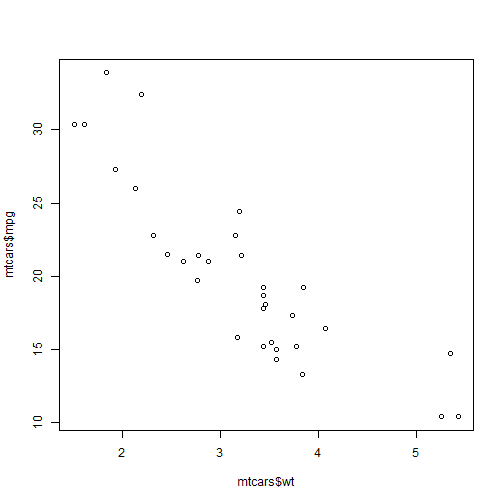

```r
plot(mtcars$wt, mtcars$mpg)
```

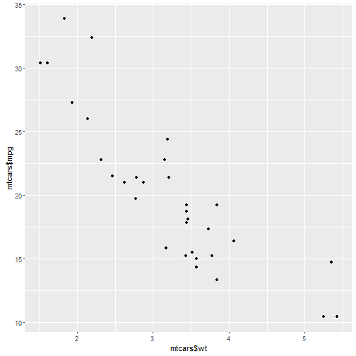

```r
qplot(mtcars$wt, mtcars$mpg)
```

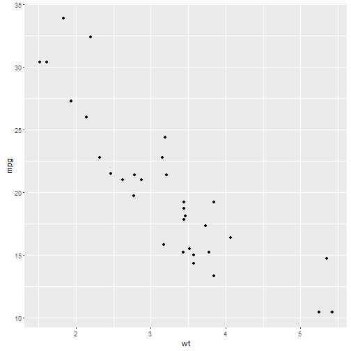

```r
qplot(wt, mpg, data = mtcars)
```

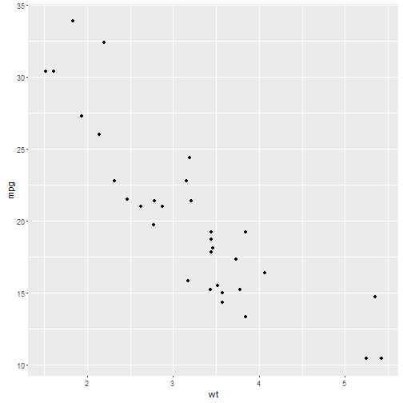

```r
ggplot(data = mtcars, aes(x = wt, y = mpg)) + geom_point()
```

### 2.2 Line Graph

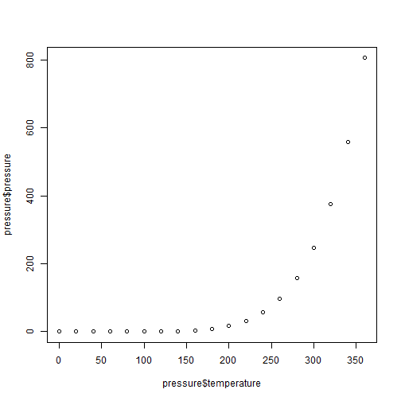

```r
plot(pressure$temperature, pressure$pressure)
```

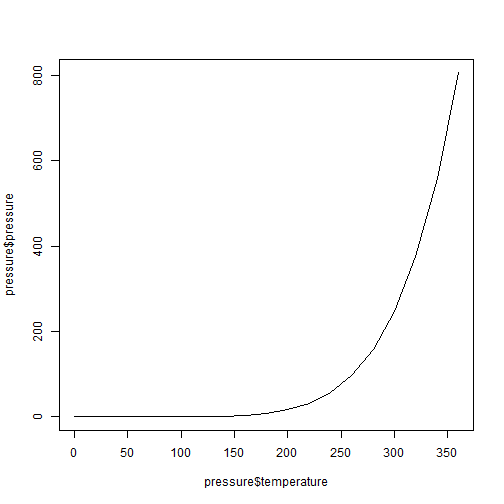

```r
plot(pressure$temperature, pressure$pressure, type = "l")
```

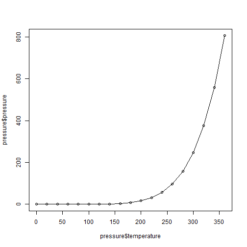

```r
plot(pressure$temperature, pressure$pressure, type = "l")
points(pressure$temperature, pressure$pressure)
```

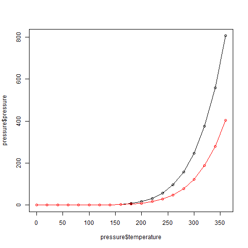

```r
plot(pressure$temperature, pressure$pressure, type = "l")
points(pressure$temperature, pressure$pressure)
lines(pressure$temperature, pressure$pressure/2, col = "red")
points(pressure$temperature, pressure$pressure/2, col = "red")
```

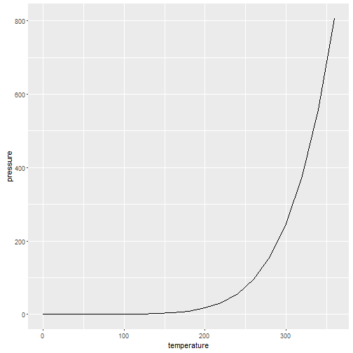

```r
qplot(temperature, pressure, data = pressure, geom = "line")
```

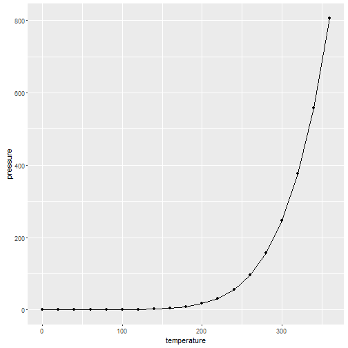

```r
qplot(temperature, pressure, data = pressure, geom = c("line", "point"))
```

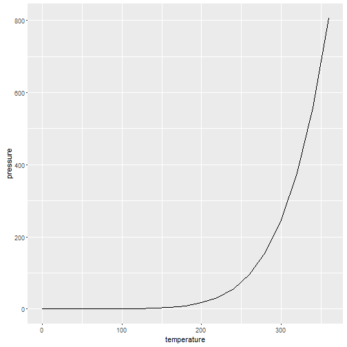

```r
ggplot(data = pressure, aes(x = temperature, y = pressure)) +
    geom_line()
```

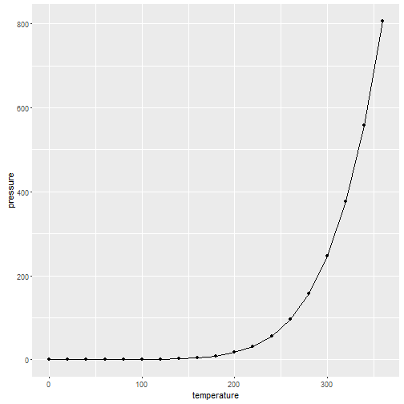

```r
ggplot(data = pressure, aes(x = temperature, y = pressure)) +
    geom_line() +
    geom_point()
```

### 2.3 Bar Graph

```r
BOD
```

```
##   Time demand
## 1    1    8.3
## 2    2   10.3
## 3    3   19.0
## 4    4   16.0
## 5    5   15.6
## 6    7   19.8
```

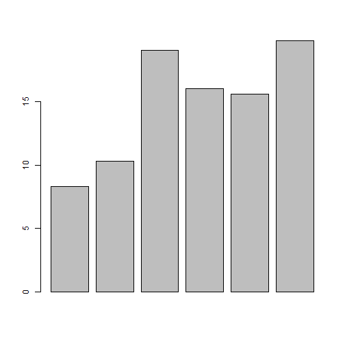

```r
barplot(BOD$demand)
```

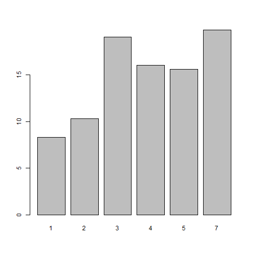

```r
barplot(BOD$demand, names.arg = BOD$Time)
```

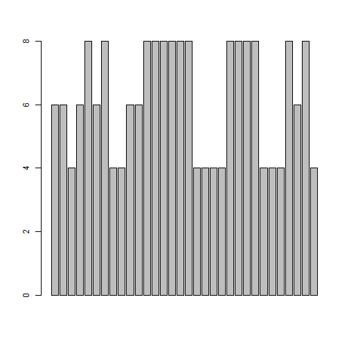

```r
barplot(mtcars$cyl)
```

```r
table(mtcars$cyl)
```

```
##
##  4  6  8
## 11  7 14
```

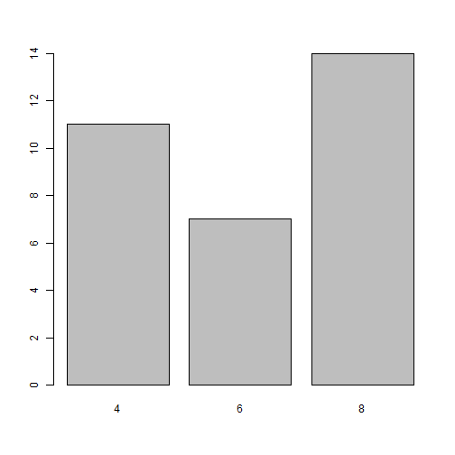

```r
barplot(table(mtcars$cyl))
```

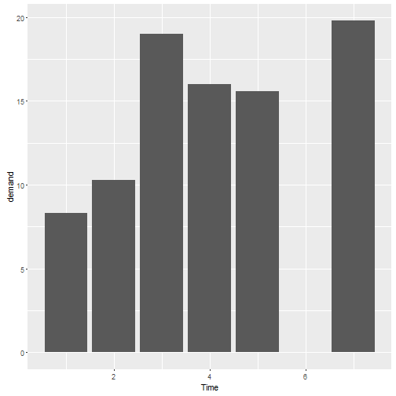

```r
ggplot(data = BOD, aes(x = Time, y = demand)) +
    geom_bar(stat = "identity")
```

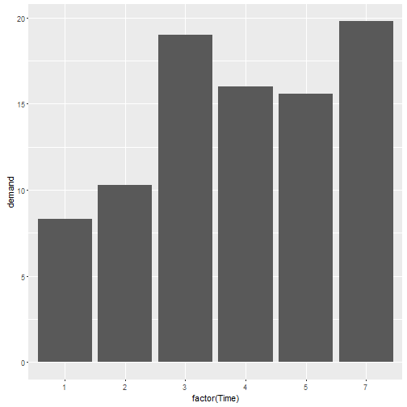

```r
# Convert the x variable to a factor, so that it is treated as discrete
ggplot(data = BOD, aes(x = factor(Time), y = demand)) +
    geom_bar(stat = "identity")
```

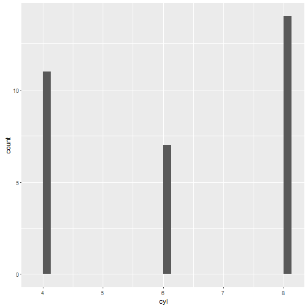

```r
qplot(cyl, data = mtcars)
```

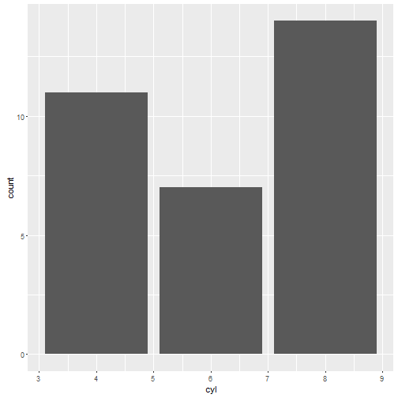

```r
ggplot(mtcars, aes(x = cyl)) + geom_bar()
```

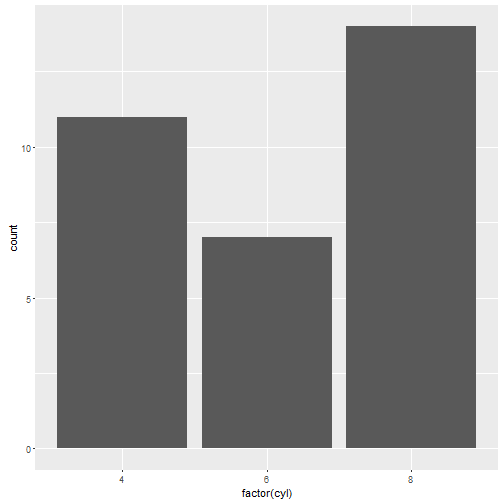

```r
qplot(factor(cyl), data = mtcars)
```

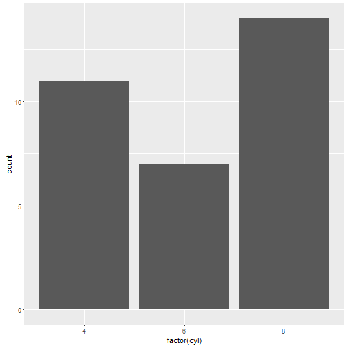

```r
ggplot(mtcars, aes(x = factor(cyl))) + geom_bar()
```

### 2.4 Histogram

#### view the distribution of one-dimensional data

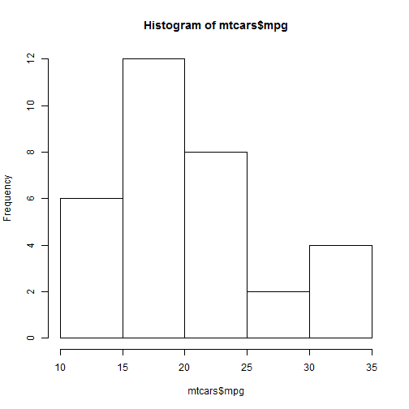

```r
hist(mtcars$mpg)
```

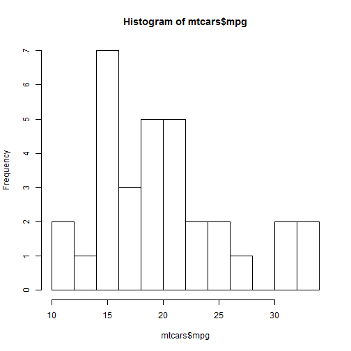

```r
hist(mtcars$mpg, breaks = 10)
```

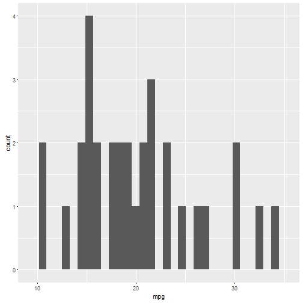

```r
qplot(mpg, data = mtcars)
```

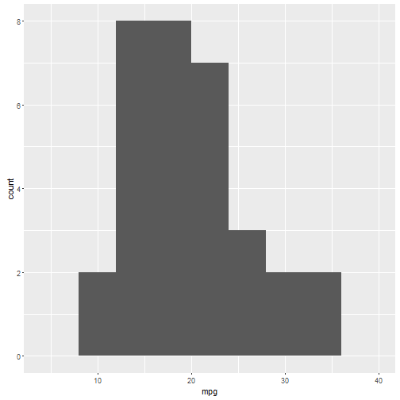

```r
qplot(mpg, data = mtcars, binwidth = 4)
```

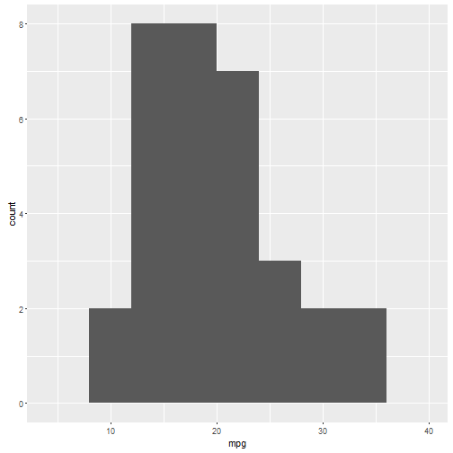

```r
ggplot(data = mtcars, aes(mpg)) +
    geom_histogram(binwidth = 4)
```

### 2.5 Box Plot

#### comparing distributions

```r
head(ToothGrowth)
```

```
##    len supp dose
## 1  4.2   VC  0.5
## 2 11.5   VC  0.5
## 3  7.3   VC  0.5
## 4  5.8   VC  0.5
## 5  6.4   VC  0.5
## 6 10.0   VC  0.5
```

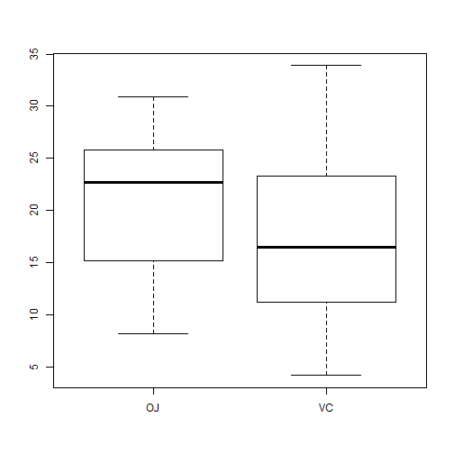

```r
plot(ToothGrowth$supp, ToothGrowth$len)
```

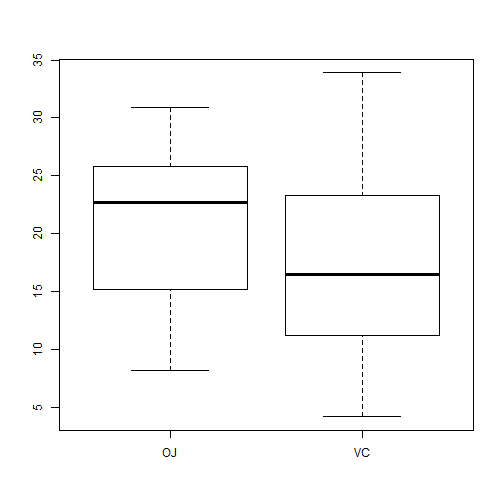

```r
boxplot(len ~ supp, data = ToothGrowth)
```

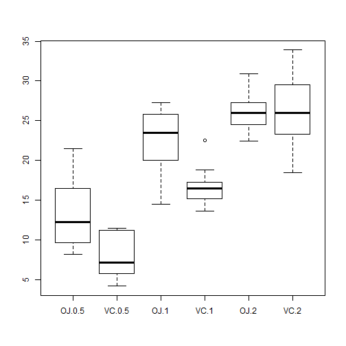

```r
boxplot(len ~ supp + dose, data = ToothGrowth)
```

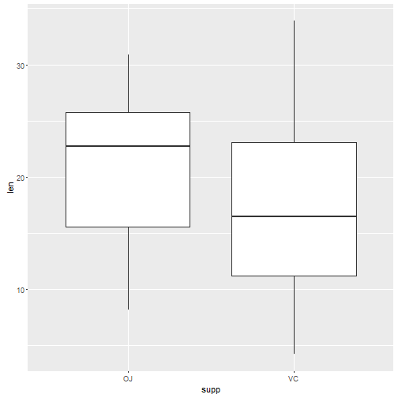

```r
qplot(x = supp, y = len, data = ToothGrowth, geom = "boxplot")
```

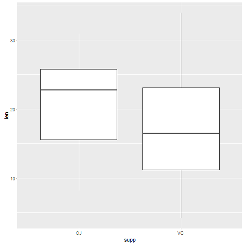

```r
ggplot(data = ToothGrowth, aes(x = supp, y = len)) +
    geom_boxplot()
```

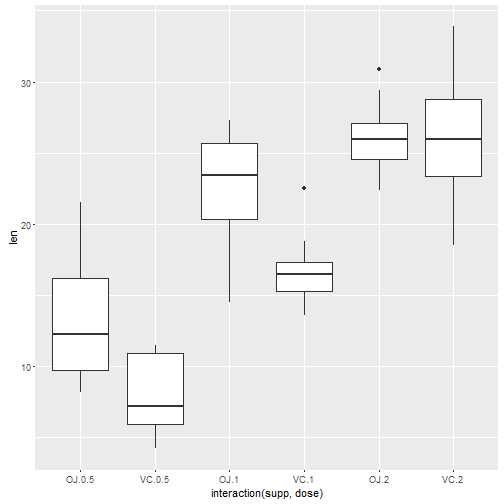

```r
qplot(x = interaction(supp, dose), y = len,
      data = ToothGrowth,
      geom = "boxplot")
```

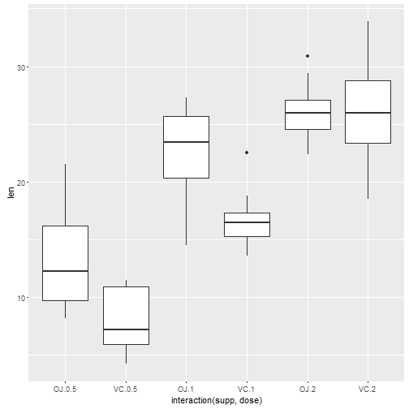

```r
ggplot(data = ToothGrowth, aes(x = interaction(supp, dose), y = len)) +
    geom_boxplot()
```

### 2.6 Function Curve

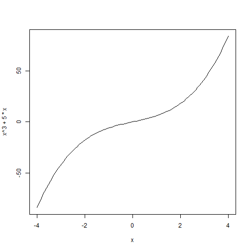

```r
curve(x^3 + 5*x, from = -4, to = 4)
```

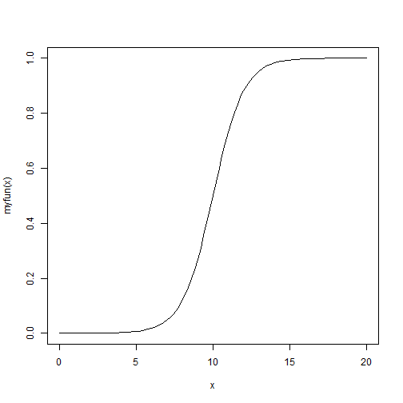

```r
myfun <- function(xvar) {
    1/(1 + exp(-xvar + 10))
}
curve(myfun(x), from = 0, to = 20)
```

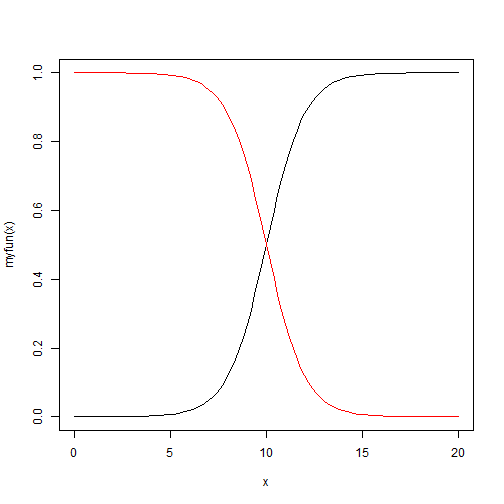

```r
curve(myfun(x), from = 0, to = 20)
curve(1-myfun(x), add = TRUE, col = "red")
```

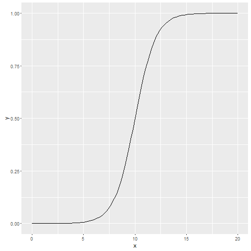

```r
ggplot(data = data.frame(x = c(0, 20)), aes(x = x)) +
    stat_function(fun = myfun, geom = "line")
```

## 3. Bar Graphs

## 5. Scatter Plots

### display the relationship between two continuous variables

### 5.1 Basic Scatter Plot

```r
head(heightweight)
```

```
##   sex ageYear ageMonth heightIn weightLb
## 1   f   11.92      143     56.3     85.0
## 2   f   12.92      155     62.3    105.0
## 3   f   12.75      153     63.3    108.0
## 4   f   13.42      161     59.0     92.0
## 5   f   15.92      191     62.5    112.5
## 6   f   14.25      171     62.5    112.0
```

```r
head(heightweight[, c("ageYear", "heightIn")])
```

```
##   ageYear heightIn
## 1   11.92     56.3
## 2   12.92     62.3
## 3   12.75     63.3
## 4   13.42     59.0
## 5   15.92     62.5
## 6   14.25     62.5
```

```r
ggplot(data = heightweight, aes(x = ageYear, y = heightIn)) +
    geom_point()
```

[output not shown]

```r
ggplot(data = heightweight, aes(x = ageYear, y = heightIn)) +
    geom_point(shape = 16)
```

[output not shown]

```r
ggplot(data = heightweight, aes(x = ageYear, y = heightIn)) +
    geom_point(shape = 19)
```

[output not shown]

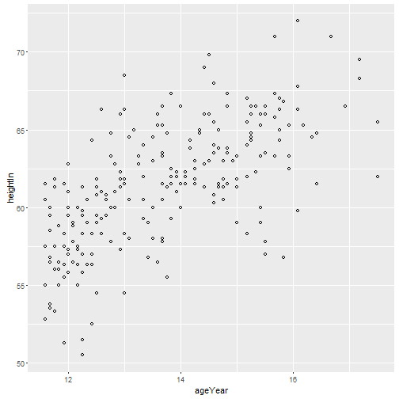

```r
ggplot(data = heightweight, aes(x = ageYear, y = heightIn)) +
    geom_point(shape = 21)
```

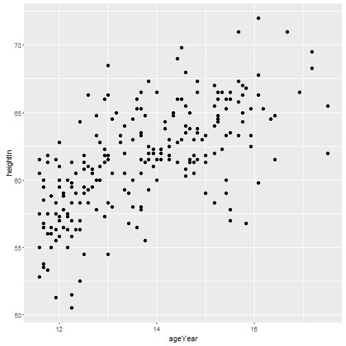

```r
ggplot(data = heightweight, aes(x = ageYear, y = heightIn)) +
    geom_point(size = 2)
```

### 5.2 Grouping Data Points by a Variable Using Shape or Color

```r
head(heightweight[, c("sex", "ageYear", "heightIn")])
```

```
##   sex ageYear heightIn
## 1   f   11.92     56.3
## 2   f   12.92     62.3
## 3   f   12.75     63.3
## 4   f   13.42     59.0
## 5   f   15.92     62.5
## 6   f   14.25     62.5
```

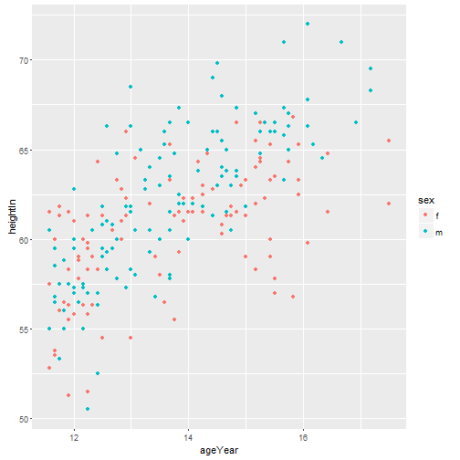

```r
ggplot(data = heightweight, aes(x = ageYear, y = heightIn, colour = sex)) +
    geom_point()
```

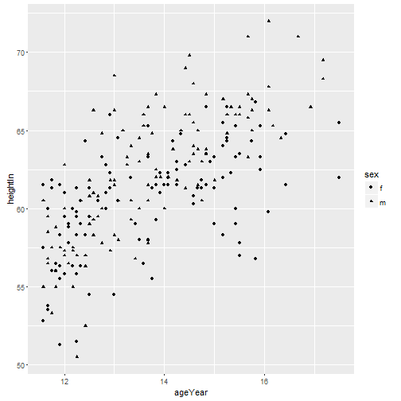

```r
ggplot(data = heightweight, aes(x = ageYear, y = heightIn, shape = sex)) +
    geom_point()
```

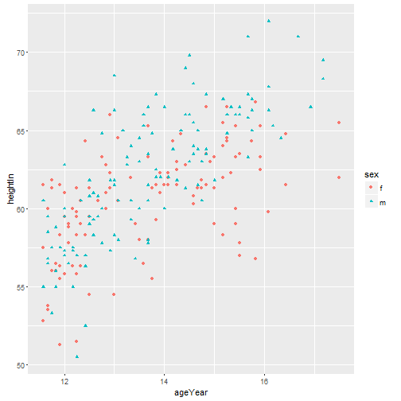

```r
ggplot(data = heightweight, aes(x = ageYear, y = heightIn, shape = sex, colour = sex)) +
    geom_point()
```

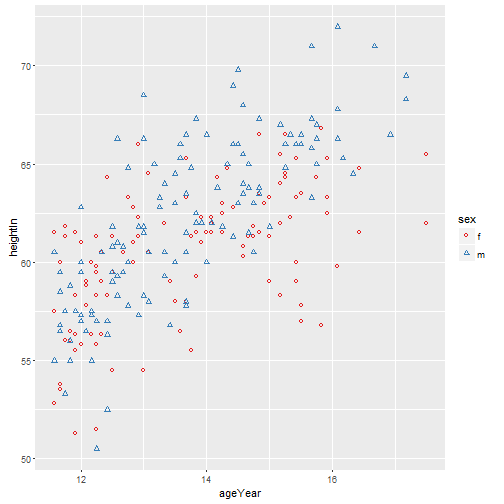

```r
ggplot(data = heightweight, aes(x = ageYear, y = heightIn, shape = sex, colour = sex)) +
    geom_point() +
    scale_shape_manual(values = c(1, 2)) +
    scale_colour_brewer(palette = "Set1")
```

```r
##  scale_colour_manual()
```

### 5.3 Using Different Point Shapes

#### Point Shapes

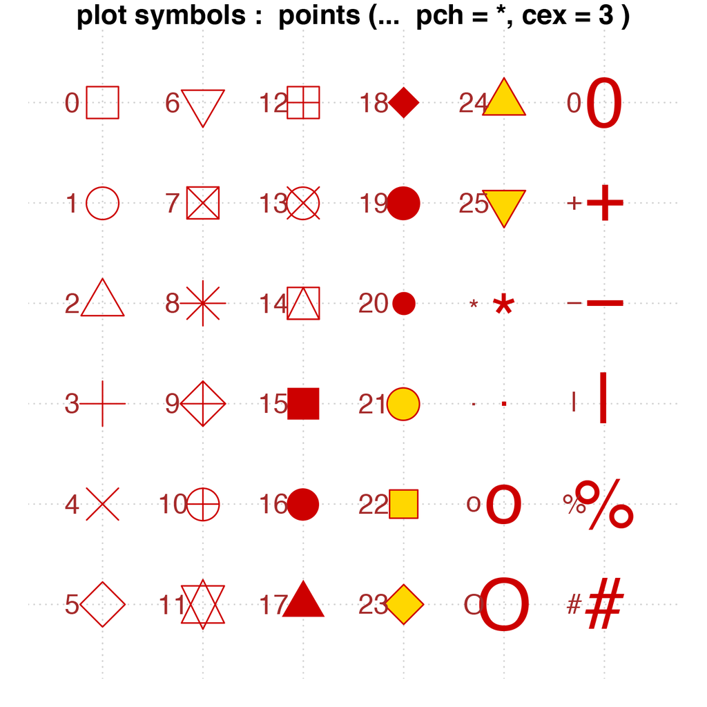

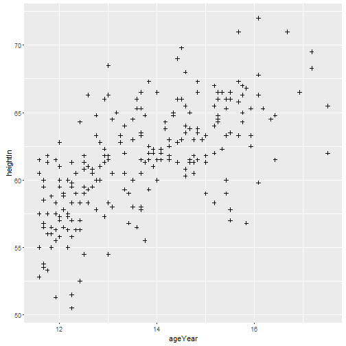

```r
ggplot(data = heightweight, aes(x = ageYear, y = heightIn)) +
    geom_point(shape = 3)
```

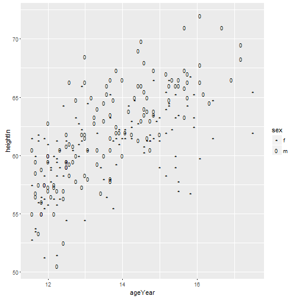

```r
ggplot(heightweight, aes(x = ageYear, y = heightIn, shape = sex)) +
    geom_point(size = 3) +
    scale_shape_manual(values = c("*", "0"))
```

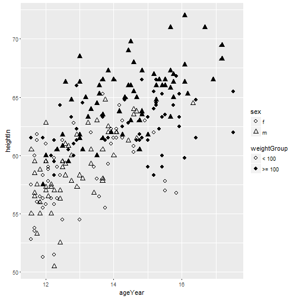

```r
# Make a copy of the data
hw <- heightweight
# Categorize into <100 and >=100 groups
hw$weightGroup <- cut(hw$weightLb,
                      breaks = c(-Inf, 100, Inf),
                      labels = c("< 100", ">= 100"))
# Use shapes with fill and color, and use colors that are empty (NA) and filled
ggplot(hw, aes(x = ageYear, y = heightIn, shape = sex, fill = weightGroup)) +
    geom_point(size = 2.5) +
    scale_shape_manual(values = c(21, 24)) +
    scale_fill_manual(values = c(NA, "black"),
                      guide = guide_legend(override.aes = list(shape = 21)))
```

### 5.4 Mapping a Continuous Variable to Color or Size

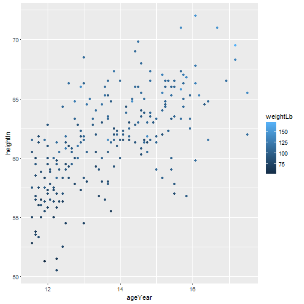

```r
ggplot(data = heightweight, aes(x = ageYear, y = heightIn, colour = weightLb)) +
    geom_point()
```

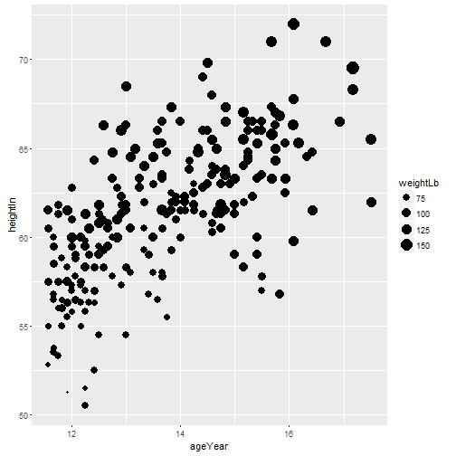

```r
ggplot(data = heightweight, aes(x = ageYear, y = heightIn, size = weightLb)) +
    geom_point()
```

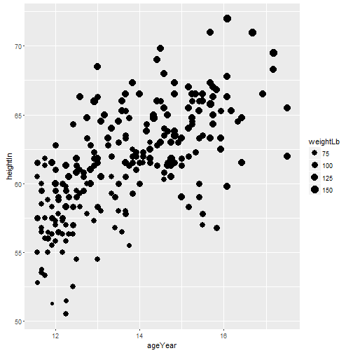

```r
ggplot(data = heightweight, aes(x = ageYear, y = heightIn, size = weightLb)) +
    geom_point() +
    scale_size_continuous(range=c(2, 5))
```

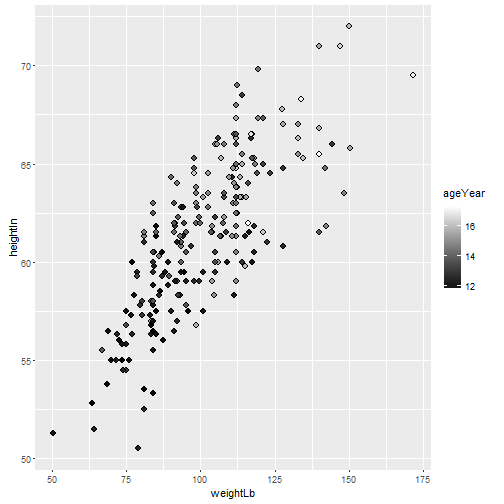

```r
ggplot(heightweight, aes(x = weightLb, y = heightIn, fill = ageYear)) +
    geom_point(shape = 21, size = 2.5) +
    scale_fill_gradient(low = "black", high = "white")
```

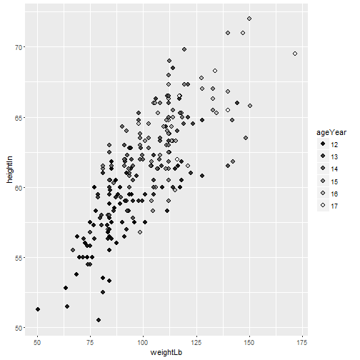

```r
# Using guide_legend() will result in a discrete legend instead of a colorbar
ggplot(heightweight, aes(x = weightLb, y = heightIn, fill = ageYear)) +
    geom_point(shape = 21, size = 2.5) +
    scale_fill_gradient(low = "black", high = "white", breaks = 12:17, guide = guide_legend())
```

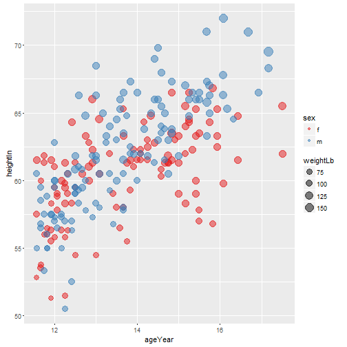

```r
ggplot(heightweight, aes(x=ageYear, y=heightIn, size=weightLb, colour=sex)) +
geom_point(alpha=.5) +
scale_size_area() + # Make area proportional to numeric value
scale_colour_brewer(palette="Set1")
```

## 11. Facets

### Rendering groups of data alongside each other, making it easy to compare the groups

### Create a subplot for each group and draw the subplots side by side

`Main Function:`

- facet_grid()
- facet_wrap()